# Mindfulness & Biofeedback meta-analysis

Ivan Ropovik & Alessandro Sparacio

2021-05-23

# Meta-analysis results

**RVE SEs with Satterthwaite small-sample correction** Estimate based on a multilevel RE model with constant sampling correlation model (CHE - correlated hierarchical effects - working model) (Pustejovsky & Tipton, 2020; https://osf.io/preprints/metaarxiv/vyfcj/). Interpretation of naive-meta-analysis should be based on these estimates.

**Prediction interval** Shows the expected range of true effects in similar studies. As an approximation, in 95% of cases the true effect in a new *published* study can be expected to fall between PI LB and PI UB. Note that these are non-adjusted estimates. An unbiased newly conducted study will more likely fall in an interval centered around bias-adjusted estimate with a wider CI width.

**Heterogeneity** Tau can be interpreted as the total amount of heterogeneity in the true effects. I^2$ represents the ratio of true heterogeneity to total variance across the observed effect estimates. Estimates calculated by 2 approaches are reported. This is followed by separate estimates of between- and within-cluster heterogeneity and estimated intra-class correlation of underlying true effects.

**Proportion of significant results** What proportion of effects were statistically at the alpha level of .05.

**ES-precision correlation** Kendalls’s correlation between the ES and precision

**4/3PSM** Applies a permutation-based, step-function 4-parameter selection model (one-tailed p-value steps = c(.025, .5, 1)). Falls back to 3-parameter selection model if at least one of the three p-value intervals contains less than 4 p-values.

pvalue = p-value testing H0 that the effect is zero. ciLB and ciUB are lower and upper bound of the CI. k = number of studies. steps = 3 means that the 4PSM was applied, 2 means that the 3PSM was applied.

**PET-PEESE** Estimated effect size of an infinitely precise study. Using 4/3PSM as the conditional estimator instead of PET (can be changed to PET). If the PET-PEESE estimate is in the opposite direction, the effect can be regarded nil. By default (can be changed to PET), the function employs a modified sample-size based estimator (see https://www.jepusto.com/pet-peese-performance/). It also uses the same RVE sandwich-type based estimator in a CHE (correlated hierarchical effects) working model with the identical random effects structure as the primary (naive) meta-analytic model.

Name of the estimate parameter denotes whether PET or PEESE was applied.

**WAAP-WLS** Combined WAAP-WLS estimator (weighted average of the adequately powered - weighted least squares). The method tries to identify studies that are adequately powered to detect the meta-analytic effect. If there’s none or only one such study, the methods falls back to WLS estimator (Stanley & Doucouliagos, 2015). If there are at least two, WAAP returns a WLS estimate based on only effects from those studies

type = 1: WAAP estimate, 2: WLS estimate. kAdequate = number of adequately powered studies

**p-uniform** Permutation-based new version of p-uniform method, the so-called p-uniform* (van Aert, van Assen, 2021).

**p-curve** Permutation-based p-curve method. Output should be pretty self-explanatory.

**Power for detecting SESOI and bias-corrected parameter estimates** Estimates of the statistical power for detecting a smallest effect sizes of interest equal to .20, .50, and .70 in SD units (Cohen’s d). A sort of a thought experiment, we also assumed that population true values equal the bias-corrected estimates (4/3PSM or PET-PEESE) and computed power for those.

**Handling of dependencies in bias-correction methods** To handle dependencies among the effects, the 4PSM, p-curve, p-uniform are implemented using a permutation-based procedure, randomly selecting only one focal effect (i.e., excluding those which were not coded as being focal) from a single study and iterating nIterations times. Lastly, the procedure selects the result with the median value of the ES estimate (4PSM, p-uniform) or median z-score of the full p-curve (p-curve).

## Self-administered mindfulness

```
## $`RMA results with model-based SEs`
##
## Multivariate Meta-Analysis Model (k = 35; method: REML)
##
## Variance Components:
##
##             estim    sqrt  nlvls  fixed        factor
## sigma^2.1  0.0288  0.1696     14     no         study
## sigma^2.2  0.0573  0.2393     35     no  study/result
##
## Test for Heterogeneity:
## Q(df = 34) = 86.2105, p-val < .0001
##
## Model Results:
##
## estimate      se    zval    pval   ci.lb   ci.ub
##   0.3739  0.0847  4.4147  <.0001  0.2079  0.5398  ***
##
## ---
## Signif. codes:  0 '***' 0.001 '**' 0.01 '*' 0.05 '.' 0.1 ' ' 1
##
##
## $`RVE SEs with Satterthwaite small-sample correction`
## $`RVE SEs with Satterthwaite small-sample correction`$test
##     Coef. Estimate     SE t-stat d.f. p-val (Satt) Sig.
## 1 intrcpt    0.374 0.0846   4.42 12.2       <0.001  ***
##
## $`RVE SEs with Satterthwaite small-sample correction`$CIs
##      Coef Estimate     SE d.f. Lower 95% CI Upper 95% CI
## 1 intrcpt    0.374 0.0846 12.2         0.19        0.558
##
##
## $`Prediction interval`
## 95% PI LB 95% PI UB
##    -0.286     1.033
##
## $Heterogeneity
##                           Tau                           I^2
##                     0.2933182                    59.7904716
##                 Jackson's I^2 Between-cluster heterogeneity
```

[output cut: 56 more lines]

```
## - Evidential value present: yes
## - Evidential value absent/inadequate: no
##
##
## $`Power for detecting SESOI and bias-corrected parameter estimates`
##              Median power for detecting a SESOI of d = .20
##                                                      0.210
##              Median power for detecting a SESOI of d = .50
##                                                      0.819
##              Median power for detecting a SESOI of d = .70
##                                                      0.980
## Median power for detecting PET-PEESE estimate.PET estimate
##                                                      0.148
##             Median power for detecting 4/3PSM estimate.est
##                                                      0.293
```

## Biofeedback

```
## $`RMA results with model-based SEs`
##
## Multivariate Meta-Analysis Model (k = 31; method: REML)
##
## Variance Components:
##
##             estim    sqrt  nlvls  fixed        factor
## sigma^2.1  0.0494  0.2223     13     no         study
## sigma^2.2  0.1117  0.3343     31     no  study/result
##
## Test for Heterogeneity:
## Q(df = 30) = 90.0679, p-val < .0001
##
## Model Results:
##
## estimate      se    zval    pval   ci.lb   ci.ub
##   0.5901  0.1233  4.7860  <.0001  0.3485  0.8318  ***
##
## ---
## Signif. codes:  0 '***' 0.001 '**' 0.01 '*' 0.05 '.' 0.1 ' ' 1
##
##
## $`RVE SEs with Satterthwaite small-sample correction`
## $`RVE SEs with Satterthwaite small-sample correction`$test
##     Coef. Estimate    SE t-stat d.f. p-val (Satt) Sig.
## 1 intrcpt     0.59 0.122   4.84 10.3       <0.001  ***
##
## $`RVE SEs with Satterthwaite small-sample correction`$CIs
##      Coef Estimate    SE d.f. Lower 95% CI Upper 95% CI
## 1 intrcpt     0.59 0.122 10.3         0.32        0.861
##
##
## $`Prediction interval`
## 95% PI LB 95% PI UB
##    -0.324     1.505
##
## $Heterogeneity
##                           Tau                           I^2
##                     0.4014309                    61.6598749
##                 Jackson's I^2 Between-cluster heterogeneity
```

[output cut: 56 more lines]

```
## - Evidential value present: yes
## - Evidential value absent/inadequate: no
##
##
## $`Power for detecting SESOI and bias-corrected parameter estimates`
##              Median power for detecting a SESOI of d = .20
##                                                    "0.111"
##              Median power for detecting a SESOI of d = .50
##                                                    "0.438"
##              Median power for detecting a SESOI of d = .70
##                                                    "0.714"
## Median power for detecting PET-PEESE estimate.PET estimate
##                    "ES estimate in the opposite direction"
##             Median power for detecting 4/3PSM estimate.est
##                                                    "0.308"
```

# Plots

## Contour enhanced funnel plot

### Mindfulness

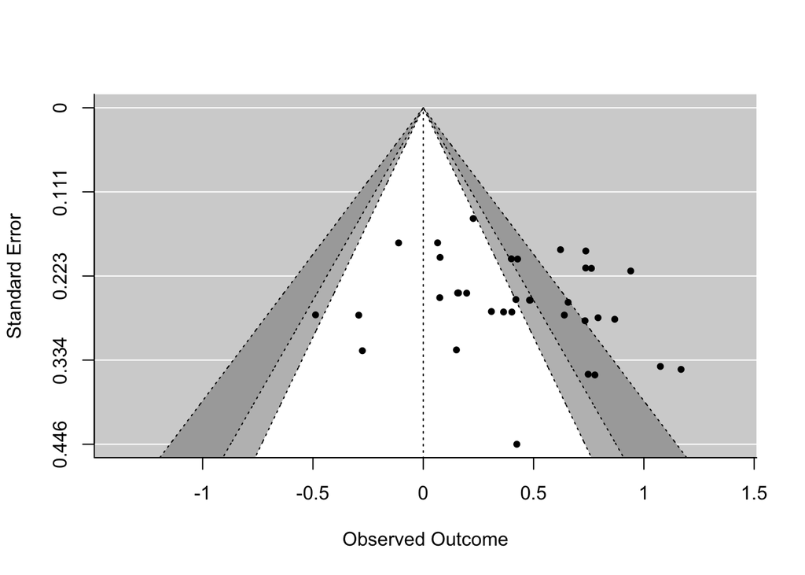

### Biofeedback

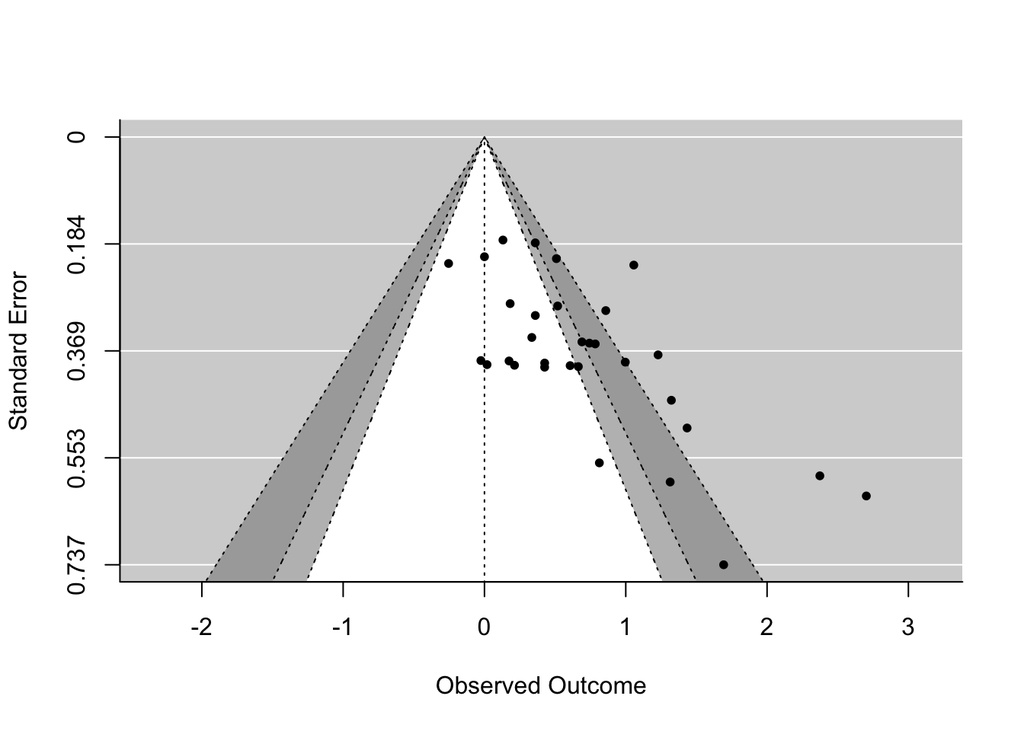

## Forest plots

### Mindfulness

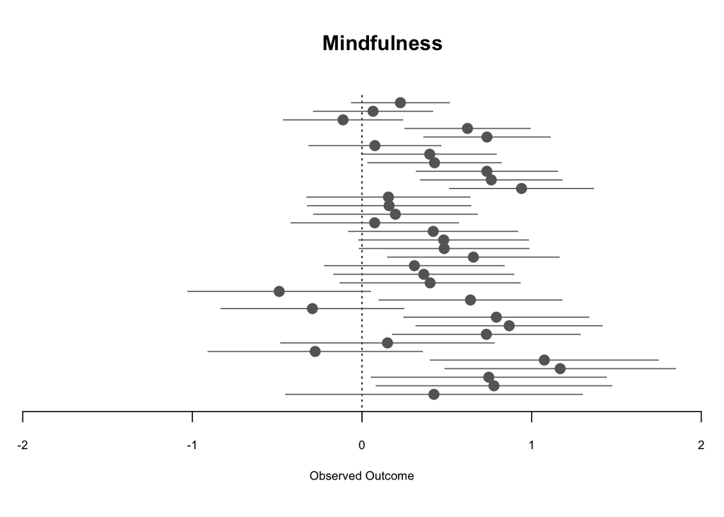

### Biofeedback

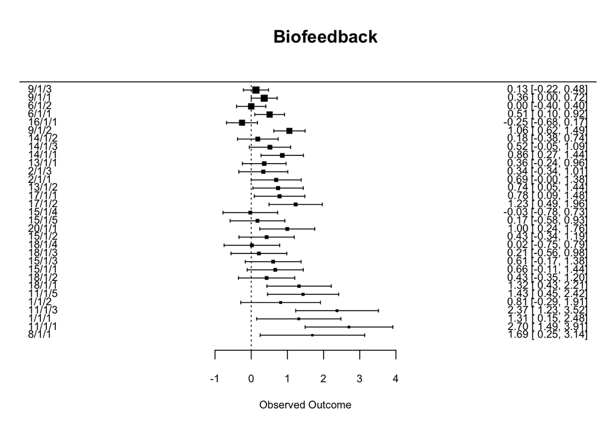

## p-curve plots

### Mindfulness

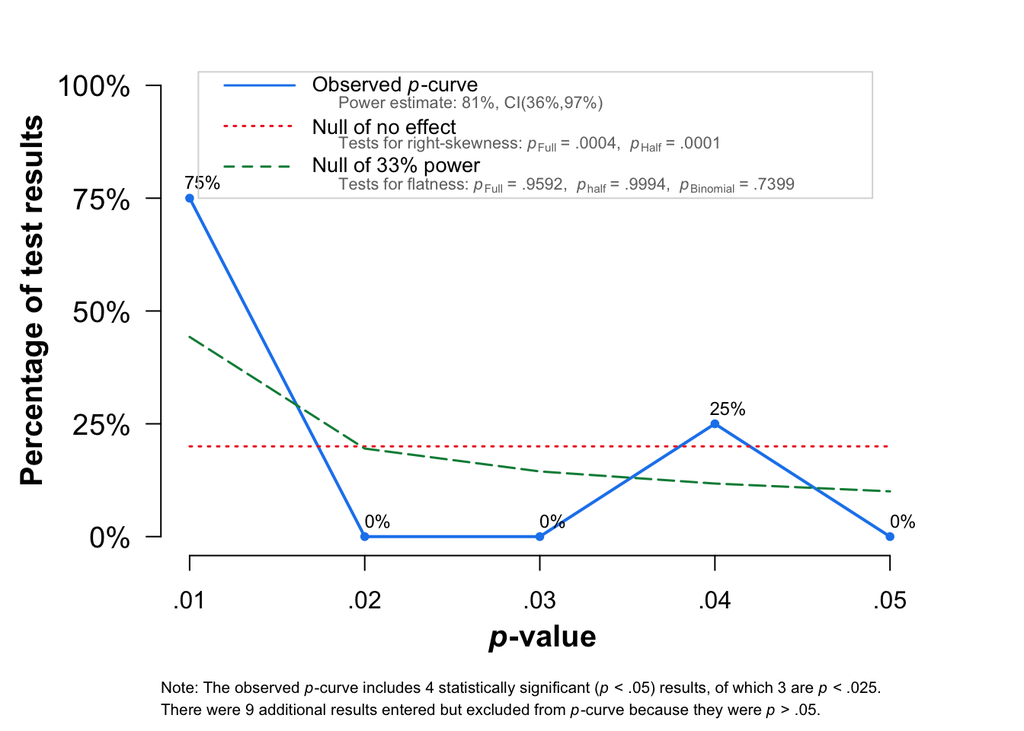

### Biofeedback

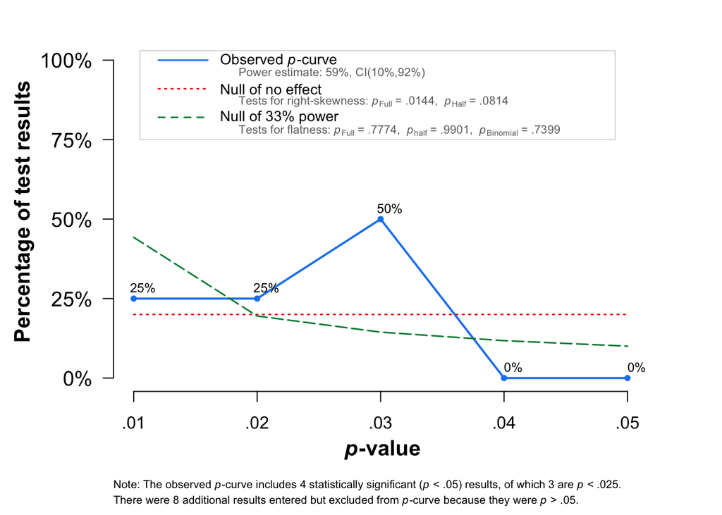

## PET-PEESE plots

Using the sqrt(2/n) and 2/n terms instead of SE and var for PET and PEESE, respectively since modified sample-size based estimator was implemented (see https://www.jepusto.com/pet-peese-performance/).

### Mindfulness

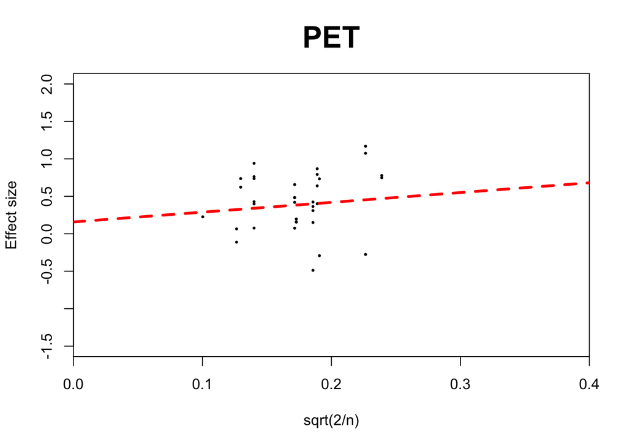

### Biofeedback

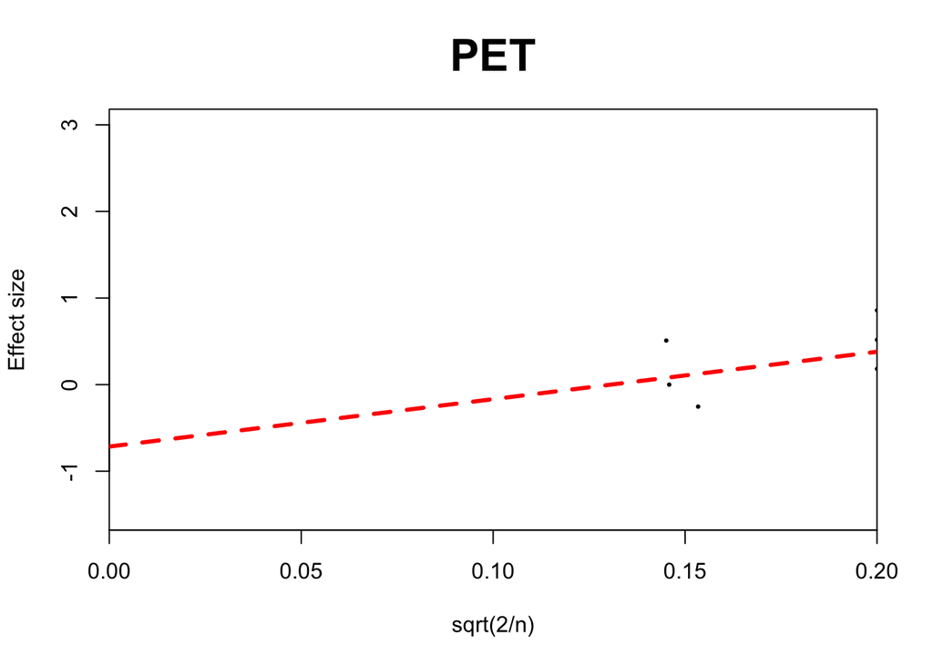

## Moderator analysis for the number of intervention sessions

```
## $`Self-administered mindfulness`
## $`Self-administered mindfulness`$`Number of intervention sessions`
##
##  1  6 10 14 40 42 48 64
##  2  3  2  2  1  2  3  3
##
## $`Self-administered mindfulness`$`Model results`
##                Coef. Estimate      SE t-stat p-val (z) Sig.
## 1 interventionNumber  0.00837 0.00433   1.93    0.0533    .
##
##
## $Biofeedback
## $Biofeedback$`Number of intervention sessions`
##
##  1  3  4  5  6 10 14 40
##  7  2  2  2  7  3  5  3
##
## $Biofeedback$`Model results`
##                Coef. Estimate     SE t-stat p-val (z) Sig.
## 1 interventionNumber   0.0317 0.0311   1.02     0.307
```

## Moderator analysis for the frequency of intervention

```
## $`Self-administered mindfulness`
## $`Self-administered mindfulness`$`Frequency of intervention sessions`
##
##  0  1  2  4  5  6  7
##  2  4  3  2  6  2 11
##
## $`Self-administered mindfulness`$`Model results`
##                   Coef. Estimate     SE t-stat p-val (z) Sig.
## 1 interventionFrequency    0.067 0.0142    4.7    <0.001  ***
##
##
## $Biofeedback
## $Biofeedback$`Frequency of intervention sessions`
##
##  1  5  7
## 18  2 11
##
## $Biofeedback$`Model results`
##                   Coef. Estimate     SE t-stat p-val (z) Sig.
## 1 interventionFrequency    0.146 0.0488      3   0.00269   **
```

## Moderator analysis for the duration of intervention

```
## $`Self-administered mindfulness`
## $`Self-administered mindfulness`$`Duration of intervention sessions`
##
## 0.166666666666667  1.38333333333333  2.33333333333333               2.5
##                 2                 3                 5                 5
##                 7  10.6666666666667  13.3333333333333                16
##                 2                 3                 1                 2
##
## $`Self-administered mindfulness`$`Model results`
##                        Coef. Estimate      SE t-stat p-val (z) Sig.
## 1 I(interventionDuration/60)   0.0375 0.00893    4.2    <0.001  ***
##
##
## $Biofeedback
## $Biofeedback$`Duration of intervention sessions`
##
## 0.0833333333333333  0.166666666666667               0.25                  1
##                  2                  3                  2                  2
##                  2                2.5   3.06666666666667                3.2
##                  1                  1                  1                  5
##   3.33333333333333               10.5                 22
##                  5                  4                  3
##
## $Biofeedback$`Model results`
##                        Coef. Estimate     SE t-stat p-val (z) Sig.
## 1 I(interventionDuration/60)   0.0441 0.0343   1.28     0.199
```

## Moderator analysis for the proportion of females

```
## $`Self-administered mindfulness`
## $`Self-administered mindfulness`$`Proportion of females`
## [1] 0.8
##
## $`Self-administered mindfulness`$`Model results`
##        Coef. Estimate      SE t-stat p-val (z) Sig.
## 1 percFemale   0.0018 0.00353  0.509      0.61
##
##
## $Biofeedback
## $Biofeedback$`Proportion of females`
## [1] 0.8518519
##
## $Biofeedback$`Model results`
##        Coef. Estimate      SE t-stat p-val (z) Sig.
## 1 percFemale  0.00756 0.00244    3.1   0.00194   **
```

## Subgroup analysis for the type of the comparison group

```
## $`Self-administered mindfulness`
## $`Self-administered mindfulness`[[1]]
##
##  1  2
## 30  2
##
## $`Self-administered mindfulness`$`Model results`
##                          Coef. Estimate     SE t-stat p-val (z) Sig.
## 1 factor(comparisonGroupType)1    0.387 0.0854   4.54   < 0.001  ***
## 2 factor(comparisonGroupType)2    0.243 0.0756   3.21   0.00131   **
##
## $`Self-administered mindfulness`$`RVE Wald test`
##  test Fstat df_num df_denom p_val sig
##   HTZ   1.6      1     1.73 0.349
##
##
## $Biofeedback
## $Biofeedback[[1]]
##
##  1  2
## 23  8
##
## $Biofeedback$`Model results`
##                          Coef. Estimate    SE t-stat p-val (z) Sig.
## 1 factor(comparisonGroupType)1    0.523 0.126   4.16    <0.001  ***
## 2 factor(comparisonGroupType)2    0.820 0.373   2.20     0.028    *
##
## $Biofeedback$`RVE Wald test`
##  test Fstat df_num df_denom p_val sig
##   HTZ 0.569      1     3.19 0.502
```

## Subgroup analysis for the population type

```
## $`Self-administered mindfulness`
## $`Self-administered mindfulness`[[1]]
##
##  1  2  3
## 12 14  9
##
## $`Self-administered mindfulness`$`Model results`
##                     Coef. Estimate    SE t-stat p-val (z) Sig.
## 1 factor(populationType)1    0.308 0.165   1.87   0.06164    .
## 2 factor(populationType)2    0.424 0.139   3.05   0.00227   **
## 3 factor(populationType)3    0.338 0.116   2.91   0.00361   **
##
## $`Self-administered mindfulness`$`RVE Wald test`
##  test Fstat df_num df_denom p_val sig
##   HTZ  0.14      2     5.41 0.872
##
##
## $Biofeedback
## $Biofeedback[[1]]
##
##  1  2  3
##  3 13 15
##
## $Biofeedback$`Model results`
##                     Coef. Estimate    SE t-stat p-val (z) Sig.
## 1 factor(populationType)1    0.816 0.490   1.66   0.09629    .
## 2 factor(populationType)2    0.718 0.235   3.05   0.00227   **
## 3 factor(populationType)3    0.449 0.172   2.60   0.00927   **
##
## $Biofeedback$`RVE Wald test`
##  test Fstat df_num df_denom p_val sig
##   HTZ 0.391      2     2.19 0.716
```

## Subgroup analysis for timing of the effect

```
## $`Self-administered mindfulness`
## $`Self-administered mindfulness`[[1]]
##
##  1  2
## 35 28
##
## $`Self-administered mindfulness`$`Model results`
##                   Coef. Estimate     SE t-stat p-val (z) Sig.
## 1 factor(timingEffect)1    0.316 0.0863   3.66    <0.001  ***
## 2 factor(timingEffect)2    0.232 0.0913   2.54     0.011    *
##
## $`Self-administered mindfulness`$`RVE Wald test`
##  test Fstat df_num df_denom p_val sig
##   HTZ 0.482      1     4.54 0.522
##
##
## $Biofeedback
## $Biofeedback[[1]]
##
##  1  2
## 31  4
##
## $Biofeedback$`Model results`
##                   Coef. Estimate     SE t-stat p-val (z) Sig.
## 1 factor(timingEffect)1    0.577 0.1178   4.90    <0.001  ***
## 2 factor(timingEffect)2    0.536 0.0569   9.42    <0.001  ***
##
## $Biofeedback$`RVE Wald test`
##  test  Fstat df_num df_denom p_val sig
##   HTZ 0.0988      1     1.32 0.796
```

## Subgroup analysis for type of source

```
## [[1]]
##
##  1  2  3  4  5
## 12  4  9  5  5
##
## $`Model results`
##
## Multivariate Meta-Analysis Model (k = 35; method: REML)
##
## Variance Components:
##
##             estim    sqrt  nlvls  fixed        factor
## sigma^2.1  0.0199  0.1412     14     no         study
## sigma^2.2  0.0585  0.2418     35     no  study/result
##
## Test for Residual Heterogeneity:
## QE(df = 30) = 75.7059, p-val < .0001
##
## Test of Moderators (coefficients 1:5):
## QM(df = 5) = 26.4693, p-val < .0001
##
## Model Results:
##
##                      estimate      se    zval    pval    ci.lb   ci.ub
## factor(sourceType)1    0.3989  0.1206  3.3082  0.0009   0.1626  0.6353  ***
## factor(sourceType)2    0.0711  0.2086  0.3409  0.7332  -0.3377  0.4800
## factor(sourceType)3    0.5353  0.1948  2.7482  0.0060   0.1535  0.9171   **
## factor(sourceType)4    0.1944  0.2286  0.8507  0.3949  -0.2535  0.6424
## factor(sourceType)5    0.6741  0.2524  2.6707  0.0076   0.1794  1.1688   **
##
## ---
## Signif. codes:  0 '***' 0.001 '**' 0.01 '*' 0.05 '.' 0.1 ' ' 1
##
##
## $`RVE Wald test`
##  test Fstat df_num df_denom p_val sig
##   HTZ 0.959      4    0.286 0.774
```

# Moderator/sensitivity analyses

The below reported meta-regressions are all implemented as a multivariate RVE-based models using the CHE working model (Pustejovsky & Tipton, 2020; https://osf.io/preprints/metaarxiv/vyfcj/). Testing of contrasts is carried out using a robust Wald-type test testing the equality of estimates across levels of the moderator.

## Published status

```
## $`Self-administered mindfulness`
## $`Self-administered mindfulness`[[1]]
##
##  0  1
##  5 30
##
## $`Self-administered mindfulness`$`Model results`
##                 Coef Estimate     SE d.f. Lower 95% CI Upper 95% CI
## 1 factor(published)0    0.420 0.0190  Inf        0.382        0.457
## 2 factor(published)1    0.367 0.0935  Inf        0.184        0.550
##
## $`Self-administered mindfulness`$`RVE Wald test`
##  test Fstat df_num df_denom p_val sig
##   HTZ 0.308      1     11.8 0.589
##
##
## $Biofeedback
## $Biofeedback[[1]]
##
##  0  1
##  6 25
##
## $Biofeedback$`Model results`
##                 Coef Estimate    SE d.f. Lower 95% CI Upper 95% CI
## 1 factor(published)0   0.0878 0.307  Inf       -0.513        0.689
## 2 factor(published)1   0.6755 0.125  Inf        0.431        0.920
##
## $Biofeedback$`RVE Wald test`
##  test Fstat df_num df_denom p_val sig
##   HTZ  3.15      1     1.43 0.265
```

## Excluding effects from non-randomized designs

```
## $`Self-administered mindfulness`
## $`Self-administered mindfulness`[[1]]
##
##  1  2
## 33  2
##
## $`Self-administered mindfulness`$`Model results`
##                               Coef Estimate     SE d.f. Lower 95% CI
## 1 factor(researchDesign == 1)FALSE    0.239 0.0927  Inf       0.0575
## 2  factor(researchDesign == 1)TRUE    0.380 0.0886  Inf       0.2059
##   Upper 95% CI
## 1        0.421
## 2        0.553
##
## $`Self-administered mindfulness`$`RVE Wald test`
##  test Fstat df_num df_denom p_val sig
##   HTZ   1.2      1     1.56 0.414
##
##
## $Biofeedback
## $Biofeedback[[1]]
##
##  1  2  3
## 26  2  3
##
## $Biofeedback$`Model results`
##                               Coef Estimate    SE d.f. Lower 95% CI
## 1 factor(researchDesign == 1)FALSE    0.645 0.242  Inf        0.171
## 2  factor(researchDesign == 1)TRUE    0.600 0.154  Inf        0.299
##   Upper 95% CI
## 1        1.120
## 2        0.901
##
## $Biofeedback$`RVE Wald test`
##  test  Fstat df_num df_denom p_val sig
##   HTZ 0.0248      1     1.44 0.894
```

## Excluding effects due to inconsistent means or SDs

```
## $`Self-administered mindfulness`
## [1] NA
##
## $Biofeedback
## $Biofeedback$`Count of GRIM/GRIMMER inconsistencies`
##
## FALSE  TRUE
##    13     4
##
## $Biofeedback$`Model results`
##                                                   Coef Estimate     SE d.f.
## 1 factor(as.logical(inconsistenciesCountGRIMMER))FALSE    0.754 0.2442  Inf
## 2  factor(as.logical(inconsistenciesCountGRIMMER))TRUE    0.169 0.0802  Inf
##   Lower 95% CI Upper 95% CI
## 1       0.2751        1.232
## 2       0.0118        0.326
##
## $Biofeedback$`RVE Wald test`
##  test Fstat df_num df_denom  p_val sig
##   HTZ  5.17      1      4.2 0.0821   .
```

## Excluding effects due to a high risk of bias

```
## $`Self-administered mindfulness`
## $`Self-administered mindfulness`$`Model results`
##                                             Coef Estimate     SE d.f.
## 1 factor(robOverall > acceptableRiskOfBias)FALSE   0.3646 0.0859  Inf
## 2  factor(robOverall > acceptableRiskOfBias)TRUE   0.0103 0.2481  Inf
##   Lower 95% CI Upper 95% CI
## 1        0.196        0.533
## 2       -0.476        0.497
##
## $`Self-administered mindfulness`$`RVE Wald test`
##  test Fstat df_num df_denom p_val sig
##   HTZ  1.82      1     2.96 0.271
##
##
## $Biofeedback
## $Biofeedback$`Model results`
##                                             Coef Estimate      SE d.f.
## 1 factor(robOverall > acceptableRiskOfBias)FALSE     0.59 0.12463  Inf
## 2  factor(robOverall > acceptableRiskOfBias)TRUE     1.19 0.00653  Inf
##   Lower 95% CI Upper 95% CI
## 1        0.345        0.834
## 2        1.172        1.198
##
## $Biofeedback$`RVE Wald test`
##  test Fstat df_num df_denom  p_val sig
##   HTZ  22.8      1     10.7 <0.001 ***
```

## Comparison of strategies

### Model without covariates

```
## $`Model results`
##                Coef Estimate     SE d.f. Lower 95% CI Upper 95% CI
## 1 factor(strategy)1    0.401 0.0806  Inf        0.243        0.559
## 2 factor(strategy)2    0.562 0.1090  Inf        0.348        0.776
##
## $`RVE Wald test`
##  test Fstat df_num df_denom p_val sig
##   HTZ  1.55      1     10.8 0.239
```

### Model with covariates

Controlling for design-related factors that are prognostic w.r.t. the effect sizes (i.e., might vary across moderator categories)

```
## $`Model results`
##                  Coef Estimate    SE d.f. Lower 95% CI Upper 95% CI
## 1   factor(strategy)1  0.76640 0.585  Inf       -0.379        1.912
## 2   factor(strategy)2  1.07620 0.712  Inf       -0.318        2.471
## 3      researchDesign -0.00305 0.231  Inf       -0.457        0.451
## 4      populationType -0.11993 0.119  Inf       -0.352        0.112
## 5 comparisonGroupType -0.13401 0.444  Inf       -1.005        0.737
## 6           published  0.27741 0.330  Inf       -0.369        0.924
## 7          robOverall -0.16168 0.221  Inf       -0.595        0.271
##
## $`RVE Wald test`
##  test Fstat df_num df_denom p_val sig
##   HTZ  1.91      1     7.31 0.208
```

## Subgroup analysis for stress vs affective consequences

```
## $`Self-administered mindfulness`
## $`Self-administered mindfulness`$`Number of included effects per category`
##
##  1  2
## 32  3
##
## $`Self-administered mindfulness`$`Model results`
##                          Coef Estimate     SE d.f. Lower 95% CI Upper 95% CI
## 1 as.factor(stressAffective)1    0.353 0.0854  Inf        0.186        0.521
## 2 as.factor(stressAffective)2    0.639 0.2440  Inf        0.161        1.118
##
## $`Self-administered mindfulness`$`RVE Wald test`
##  test Fstat df_num df_denom p_val sig
##   HTZ  1.58      1        2 0.336
##
##
## $Biofeedback
## $Biofeedback$`Number of included effects per category`
##
##  1  2
## 22  9
##
## $Biofeedback$`Model results`
##                          Coef Estimate    SE d.f. Lower 95% CI Upper 95% CI
## 1 as.factor(stressAffective)1    0.574 0.125  Inf        0.329        0.819
## 2 as.factor(stressAffective)2    0.637 0.191  Inf        0.263        1.011
##
## $Biofeedback$`RVE Wald test`
##  test Fstat df_num df_denom p_val sig
##   HTZ 0.118      1     5.66 0.744
```

### Forest plots

#### Mindfulness

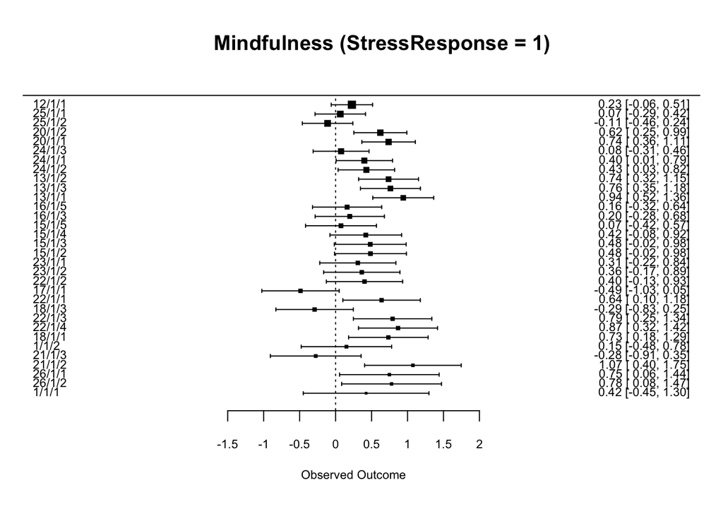

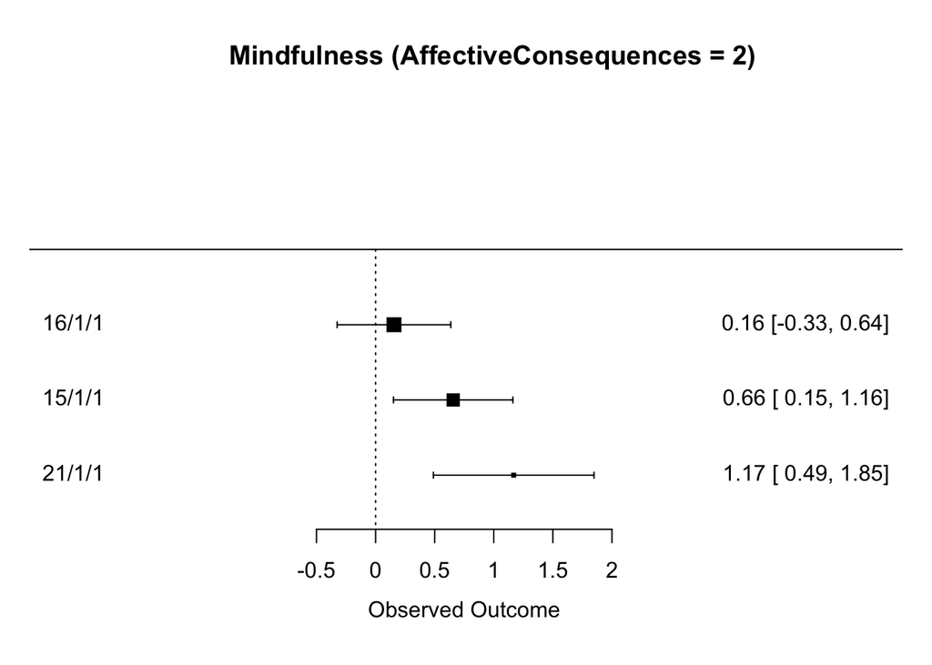

#### Biofeedback

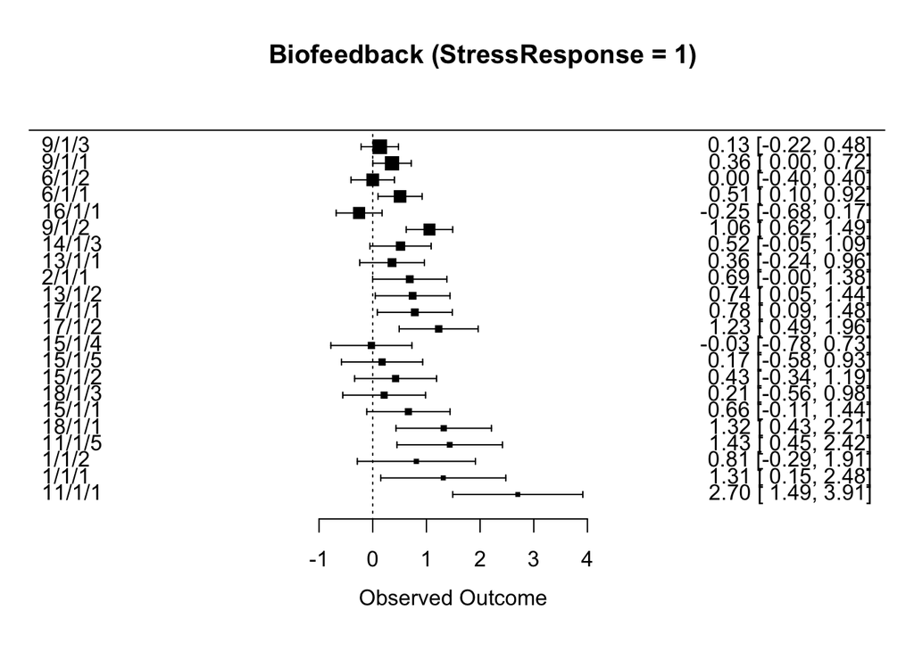

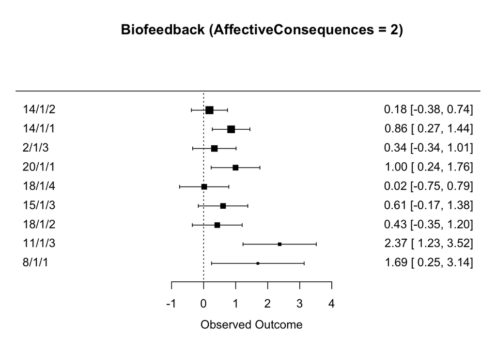

```
## $`Self-administered mindfulness`
## $`Self-administered mindfulness`$`Number of included effects per category`
##
##  1  2  3
## 26  4  2
##
## $`Self-administered mindfulness`$`Model results`
##                            Coef Estimate     SE d.f. Lower 95% CI Upper 95% CI
## 1 as.factor(stressCompRecoded)1   0.3931 0.0946  Inf      0.20758        0.579
## 2 as.factor(stressCompRecoded)2   0.0856 0.0687  Inf     -0.04904        0.220
## 3 as.factor(stressCompRecoded)3   0.2316 0.1141  Inf      0.00789        0.455
##
## $`Self-administered mindfulness`$`RVE Wald test`
##  test Fstat df_num df_denom p_val sig
##   HTZ  6.98      2     1.49 0.175
##
##
## $Biofeedback
## $Biofeedback$`Number of included effects per category`
##
##  1  2  3
## 10  1 11
##
## $Biofeedback$`Model results`
##                            Coef Estimate    SE d.f. Lower 95% CI Upper 95% CI
## 1 as.factor(stressCompRecoded)1    0.609 0.192  Inf       0.2333        0.985
## 2 as.factor(stressCompRecoded)2    0.849 0.410  Inf       0.0453        1.654
## 3 as.factor(stressCompRecoded)3    0.508 0.161  Inf       0.1929        0.822
##
## $Biofeedback$`RVE Wald test`
##  test Fstat df_num df_denom p_val sig
##   HTZ 0.274      2     3.73 0.775
```

### Forest plots

#### Mindfulness

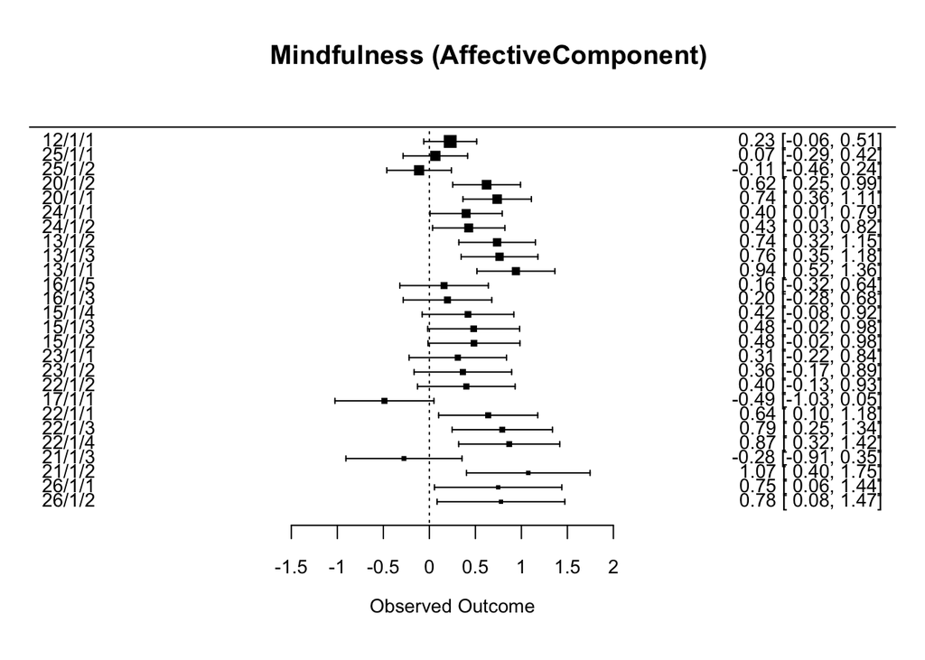

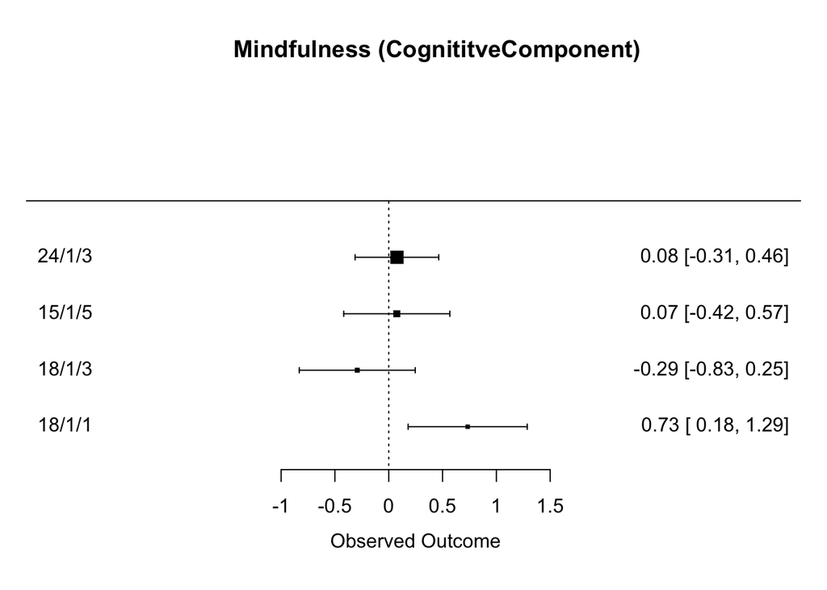

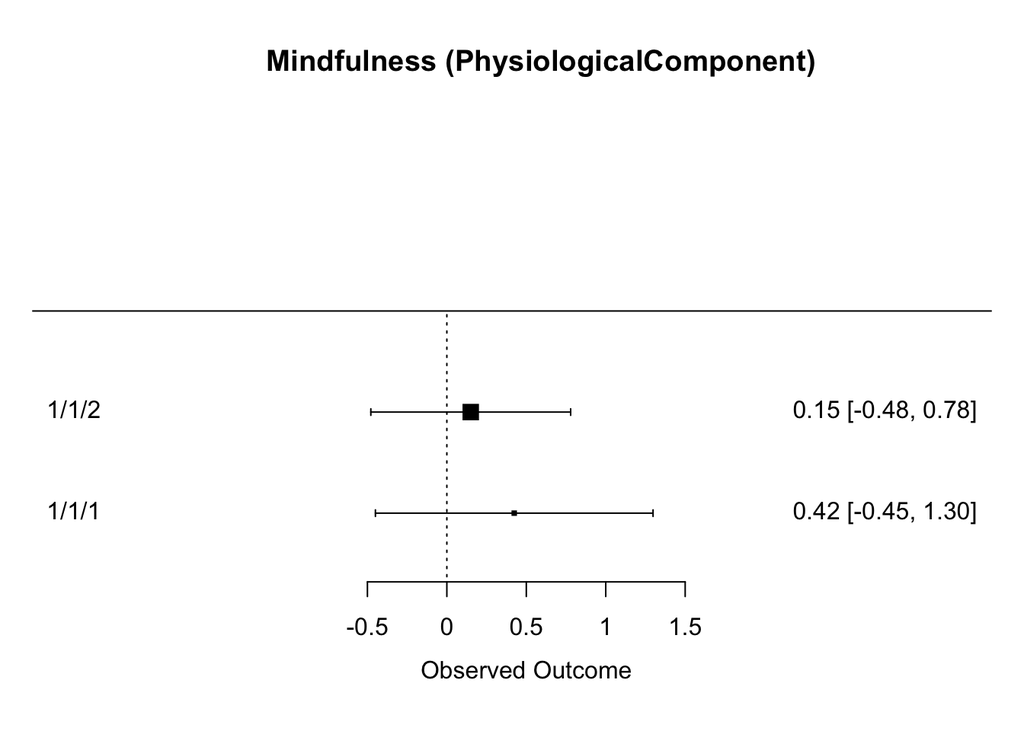

#### Biofeedback

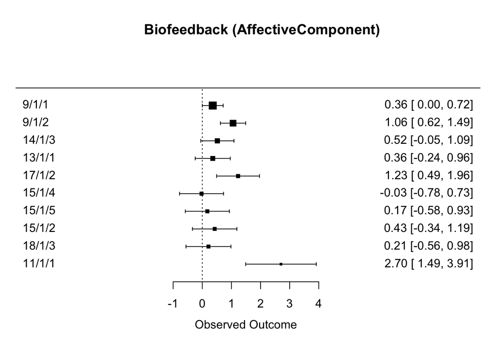

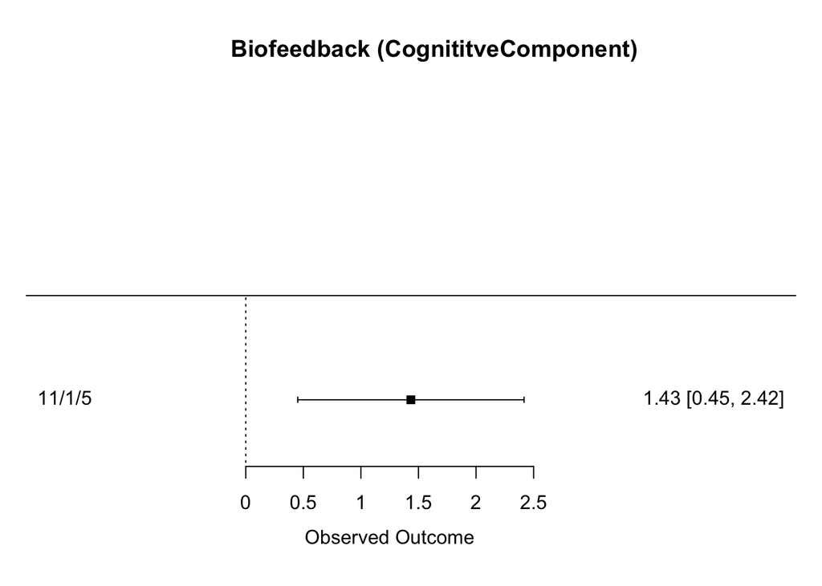

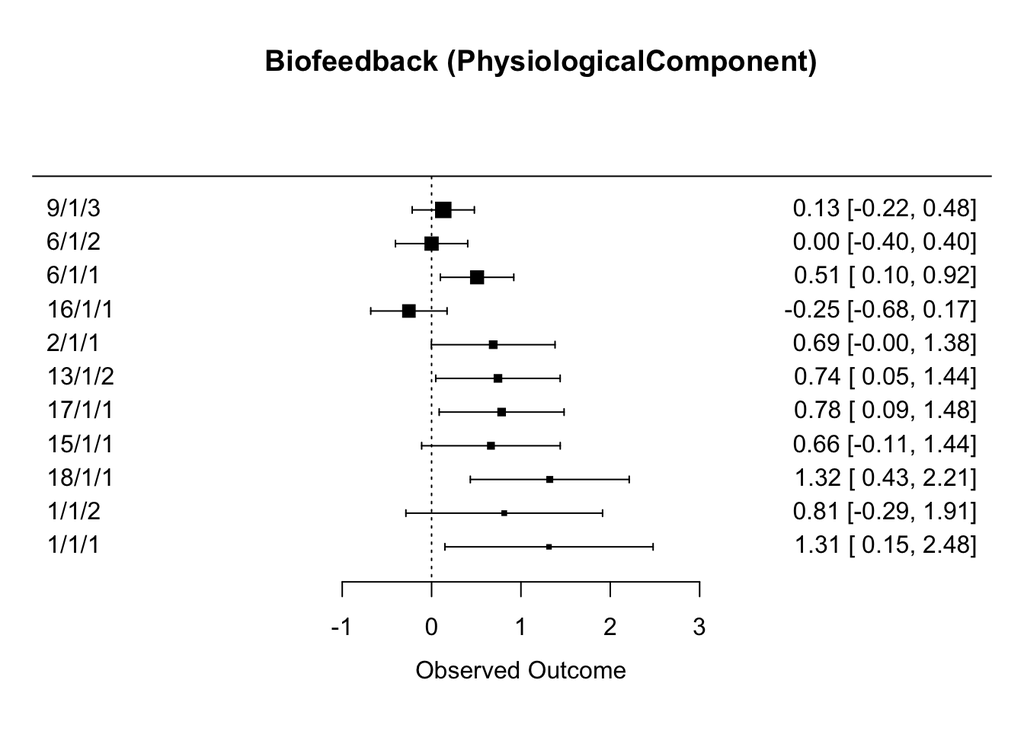